# Stats 401: Project Checkpoint

Selina Lu

2023-12-12

## Project Checkpoint

This assignment is designed for you to begin your data exploration process. Before creating a multiple linear regression model, you should always familiarize yourself with the data set and its individual variables. In this checkpoint, you will create numerical summaries and visualizations that will help guide decisions you make during your modeling process…such as:

- which predictors are helpful in explaining the response
- which variables need a transformation
- which variables could benefit from an interaction
- etc.

Most of your data sets have several predictors to choose from. For the project checkpoint, I only ask that you analyze a few of them. This will give you a baseline model called your “Initial Model”. After the checkpoint, your goal will be to try and improve upon this initial model. Remove unhelpful predictors, add helpful predictors, include transformations and interactions, etc. in order to create the best possible model for your final report. Remember, creating a regression model is an *iterative process*!

One last note is that your final model does not need to contain the variables from your project proposal (or your initial model). Explore your data and have some fun!

If you have any questions throughout the process, please ask us - the instructional team is here to help!

### Creating an RStudio Project

Now is a great time to create a dedicated RStudio Project (like you did in Lab 6) for all of your project documents. To do this, please follow these steps:

1. Open up a *new* session of RStudio
2. Navigate to File > New Project
3. Click on New Directory
4. Click on New Project
5. Give your project a “Directory name” (something like “stats401project”)
6. Decide where you would like the project stored (I keep mine - and all other Stats 401 assignments - in a folder on my computer called stats401)
7. Click “Create Project”
8. Move this “project_checkpoint.Rmd” document to the project folder
9. Move your data set to the project folder

If you are working on a team, I recommend that one student handles most of the coding - so that you don’t need to keep sending your zipped project folder back and forth. You are also welcome to use [Posit.Cloud](https://posit.cloud/learn/guide) and share a space between multiple users. If you want more information, let me know!

### Load Packages

First load in any necessary packages that you need.

```r
library(ggplot2)
```

### Read Data (2 points)

Once you have created your RStudio Project and moved your data set into the project folder, you will then be able to read in your data. Use the `read.csv()` function and store it for use throughout the file.

Reach out to us if you need help reading in your data!

```r
mortalityRates <- read.csv("cancer_mortality_rates.csv")
```

**Please do not print your entire data set.** You are welcome to provide a preview of the data set using the `head()` function, but this is not necessary.

Once you have successfully loaded your data, complete the tasks below to complete the project checkpoint. Failure to properly follow the instructions will result in point deductions.

### Variables (2 points)

Fill in the following bullet points with the variables you will be analyzing below. I recommend starting with the variables you described in your project proposal, but these can change throughout your modeling process. There is no specific number of variables that your final model has to contain.

- **Response:** cmRate: number of cancer mortalities per 100,000 people
- **Quantitative Predictor #1:** pctPrivateHC: percent of county residents with private health coverage
- **Quantitative Predictor #2:** pctEmployerHC: percent of county residents with employer-provided private health coverage
- **Quantitative Predictor #3:** pctPublicHC: percent of county residents with government-provided health coverage
- **Categorical Predictor:** region: region of county

### Numerical Summaries (3 points)

Using the `summary()` function, compute the numerical summaries for your four quantitative variables (one response + three predictors). Additionally, calculate the standard deviation of your response variable using the `sd()` function.

```r
summary(mortalityRates$cmRate)
```

```
##    Min. 1st Qu.  Median    Mean 3rd Qu.    Max.
##    94.4   161.4   177.8   179.0   195.5   293.9
```

```r
sd(mortalityRates$cmRate)
```

```
## [1] 27.3204
```

```r
summary(mortalityRates$pctPrivateHC)
```

```
##    Min. 1st Qu.  Median    Mean 3rd Qu.    Max.
##   33.50   57.90   66.20   65.03   72.70   87.50
```

```r
summary(mortalityRates$pctEmployerHC)
```

```
##    Min. 1st Qu.  Median    Mean 3rd Qu.    Max.
##   16.30   35.10   42.00   41.89   48.70   68.80
```

```r
summary(mortalityRates$pctPublicHC)
```

```
##    Min. 1st Qu.  Median    Mean 3rd Qu.    Max.
##   14.80   30.80   36.40   36.03   40.60   59.30
```

### Histograms (10 points)

Using `ggplot()`, create a histogram for each of your four quantitative variables (one response + three predictors). *Be sure to give each plot appropriate axis labels and a title.*

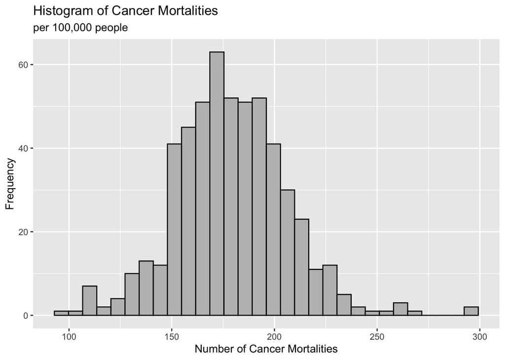

```r
ggplot(data = mortalityRates, aes(x = cmRate)) +

    geom_histogram(color = "black", fill = "grey") +

    labs(title = "Histogram of Cancer Mortalities",
         subtitle = "per 100,000 people",
         x = "Number of Cancer Mortalities",
         y = "Frequency")
```

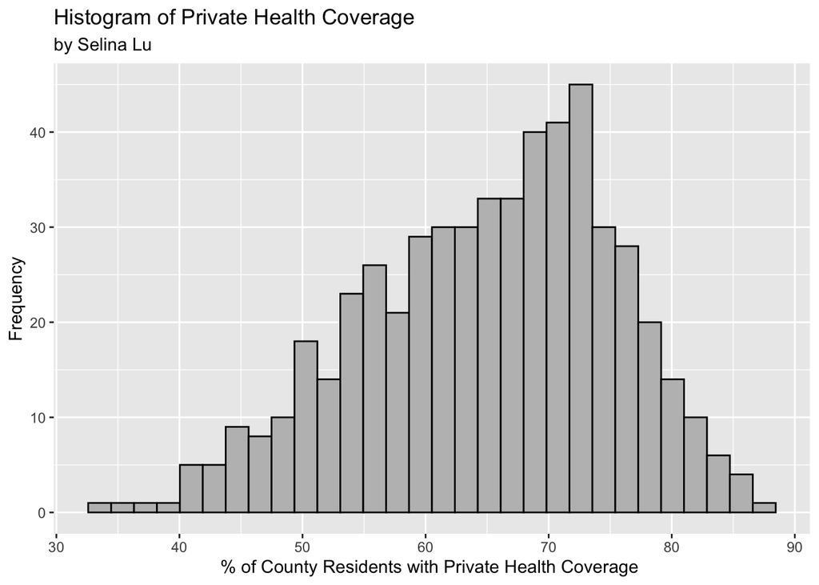

```r
ggplot(data = mortalityRates, aes(x = pctPrivateHC)) +

    geom_histogram(color = "black", fill = "grey") +

    labs(title = "Histogram of Private Health Coverage",
         subtitle = "by Selina Lu",
         x = "% of County Residents with Private Health Coverage ",
         y = "Frequency")
```

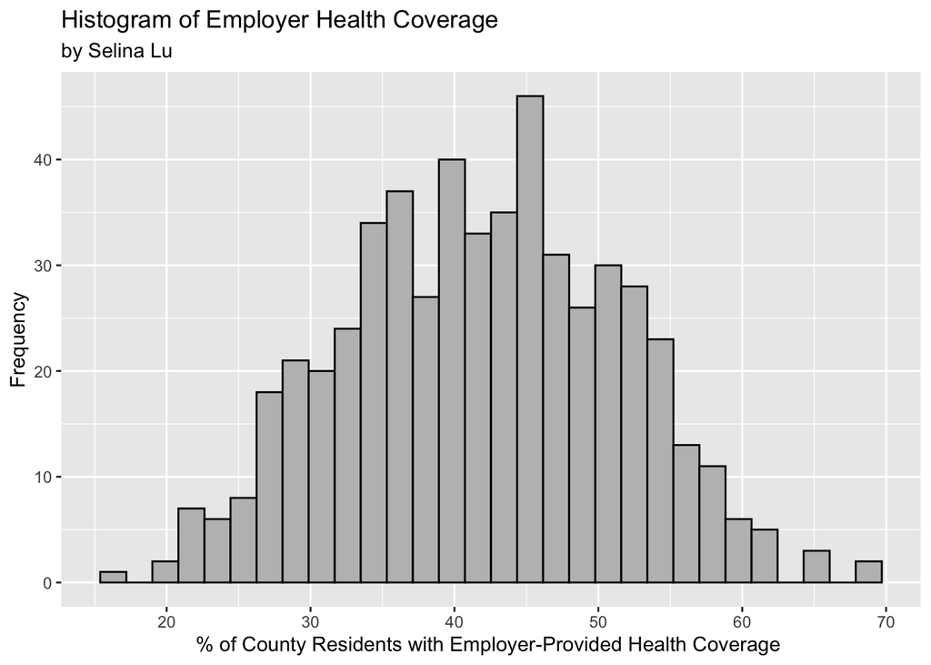

```r
ggplot(data = mortalityRates, aes(x = pctEmployerHC)) +

    geom_histogram(color = "black", fill = "grey") +

    labs(title = "Histogram of Employer Health Coverage",
         subtitle = "by Selina Lu",
         x = "% of County Residents with Employer-Provided Health Coverage ",
         y = "Frequency")
```

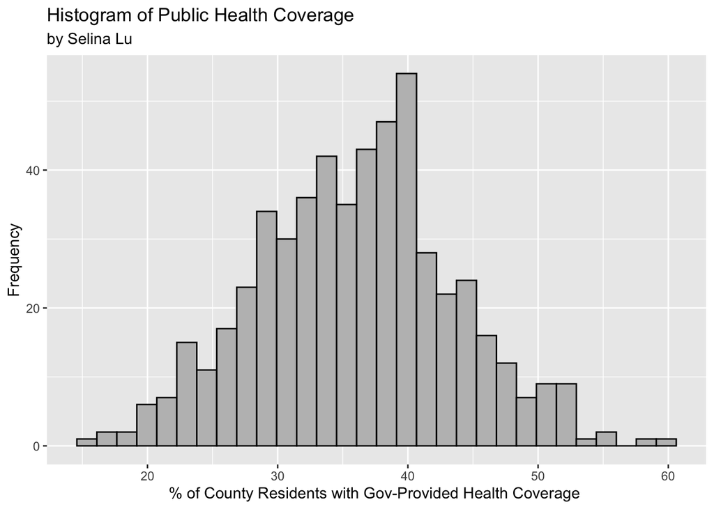

```r
ggplot(data = mortalityRates, aes(x = pctPublicHC)) +

    geom_histogram(color = "black", fill = "grey") +

    labs(title = "Histogram of Public Health Coverage",
         subtitle = "by Selina Lu",
         x = "% of County Residents with Gov-Provided Health Coverage ",
         y = "Frequency")
```

Reflect on your histograms by answering the question below.

Do any of the distributions exhibit a heavy right skew? Thinking ahead: if so, a log transformation might be helpful.

**Answer:** No, all of the distributions are approximately normal. The distribution of the histogram of Private Health Coverage is slightly left skewed.

### Scatterplot Matrix (8 points)

Create a **scatterplot matrix** of your response and the three quantitative predictors. Note: we are not asking for individual scatterplots - this will result in a deduction.

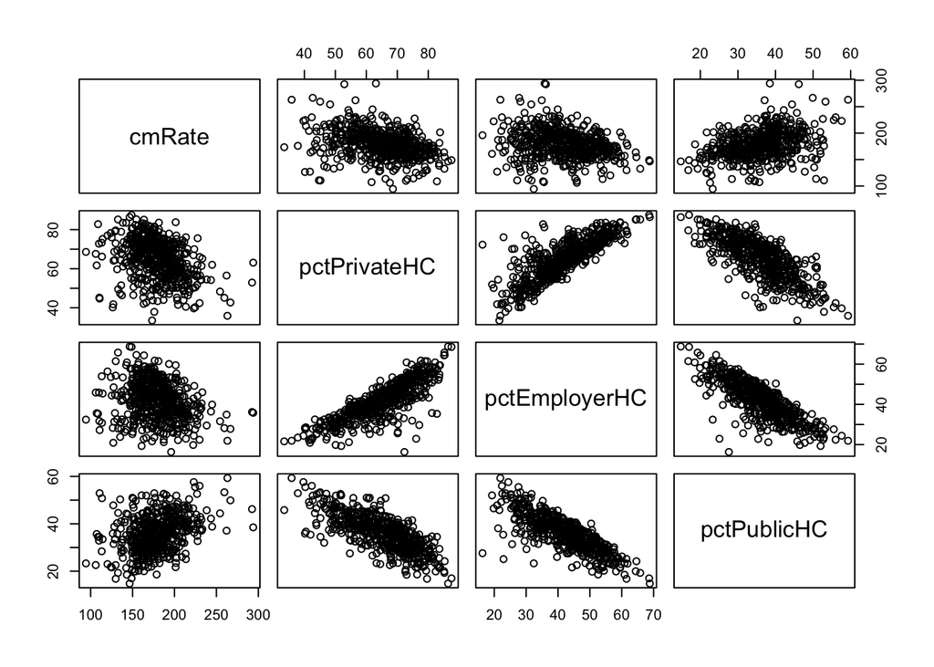

```r
plot( ~ cmRate + pctPrivateHC + pctEmployerHC + pctPublicHC, data = mortalityRates)
```

Reflect on your scatterplot matrix by answering the questions below.

Which predictor(s) seem to exhibit stronger relationships with the response?

**Answer:** The predictor pctPrivateHC or percent of county that has private health coverage seems to have a stronger relationship with the response cmRate or cancer mortality rate as the appearance of a line is more distinct cmpared to the others which have slightly less distinct lines.

Do any of the predictors have a curved relationship with the response? Thinking ahead: if so, a quadratic fit might be helpful!

**Answer:** No, none of the predictors appear to have a curved relationship with the response.

Do any of the *predictors* have a strong linear relationship with *another predictor*? Thinking ahead: if so, this could be a sign of multicollinearity. (This topic will be covered in a later lecture.)

**Answer:** Yes, all three of the predictors seem to have strong linear relationships with one another.

Important Note: if you decide to include a log transformation for any of your variables, then you should re-plot your scatterplot matrix with the transformed variable(s). This does not have to be done now though!

### Scatterplot with Color (5 points)

Select one of your three quantitative predictors from above (perhaps the one that appears to have the strong relationship with the response) and plot it against the response using `ggplot()`. Use your categorical variable to plot by color. *Be sure to give your plot appropriate axis labels and a title.*

Reminder: you may need to convert your categorical variable to a factor!

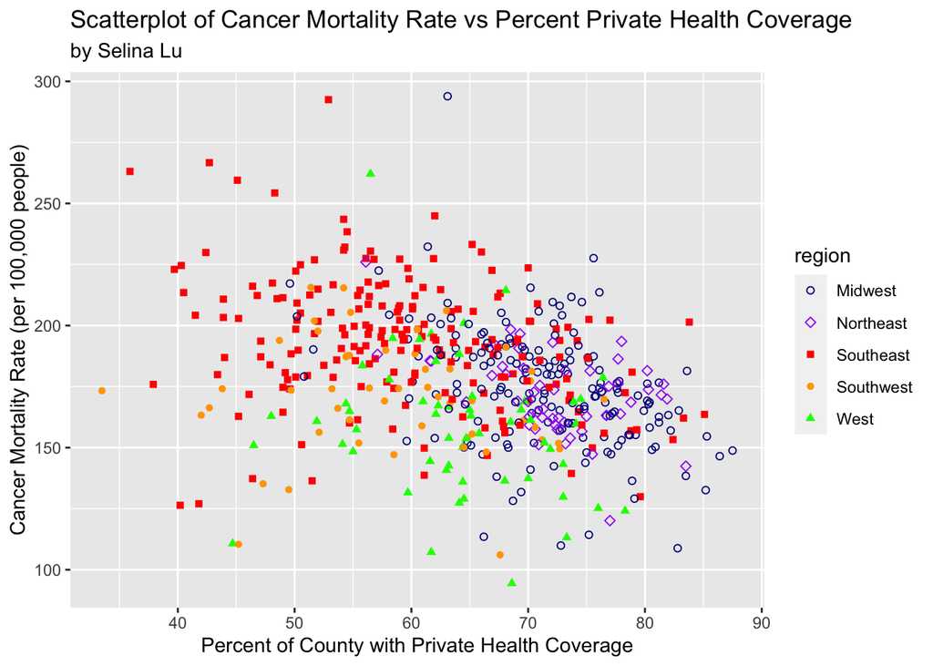

```r
ggplot(data = mortalityRates, aes(x = pctPrivateHC, y = cmRate)) +

  geom_point(aes(color = region, shape = region)) +

  labs(title = "Scatterplot of Cancer Mortality Rate vs Percent Private Health Coverage",
       subtitle = "by Selina Lu",
       x = "Percent of County with Private Health Coverage",
       y = "Cancer Mortality Rate (per 100,000 people)") +

  scale_color_manual(values = c("darkblue", "purple", "red", "orange", "green")) +
  scale_shape_manual(values = c(1, 5, 15, 16, 17))
```

Reflect on your scatterplot by answering the question below.

Does the relationship between X and Y appear to differ by group? Do these relationships appears to have different slopes? Thinking ahead: if so, an interaction might be helpful!

Note: it may be hard to conclude anything from this plot, by try to give it your best shot! (It might just look like a completely random scatter of colors.)

**Answer:** The relationship between X and Y does not appear to differ by group with a general trend of a negative relationship between cmRate and pctPrivateHC.

### Initial Model (8 points)

Create and store a linear model using all four predictor variables (the three quantitative predictors *and* the categorical predictor. Do **not** include any transformations, quadratic fits, or interactions (regardless of your answers above). Pass your stored model through the `summary()` function.

```r
mortalityRates$region <- as.factor(mortalityRates$region)
lm_cmRate <- lm(cmRate ~ region + pctPrivateHC + pctEmployerHC + pctPublicHC, data = mortalityRates)
summary(lm_cmRate)
```

```
##
## Call:
## lm(formula = cmRate ~ region + pctPrivateHC + pctEmployerHC +
##     pctPublicHC, data = mortalityRates)
##
## Residuals:
##     Min      1Q  Median      3Q     Max
## -75.968 -12.971   0.096  12.430 116.450
##
## Coefficients:
##                 Estimate Std. Error t value Pr(>|t|)
## (Intercept)     150.4018    21.6748   6.939 1.16e-11 ***
## regionNortheast  -3.9740     3.6837  -1.079 0.281171
## regionSoutheast  10.7338     2.8554   3.759 0.000189 ***
## regionSouthwest  -7.6100     4.3959  -1.731 0.084008 .
## regionWest      -18.9862     3.7267  -5.095 4.87e-07 ***
## pctPrivateHC     -0.7575     0.2080  -3.642 0.000297 ***
## pctEmployerHC     0.8252     0.2220   3.717 0.000223 ***
## pctPublicHC       1.1768     0.2567   4.584 5.69e-06 ***
## ---
## Signif. codes:  0 '***' 0.001 '**' 0.01 '*' 0.05 '.' 0.1 ' ' 1
##
## Residual standard error: 23.08 on 529 degrees of freedom
## Multiple R-squared:  0.2955, Adjusted R-squared:  0.2861
## F-statistic: 31.69 on 7 and 529 DF,  p-value: < 2.2e-16
```

Report the RMSE value and R^2 value.

**RMSE:** 23.08

**R^2:** 0.2955

For your model, create the two diagnostic plots we have discussed in lecture.

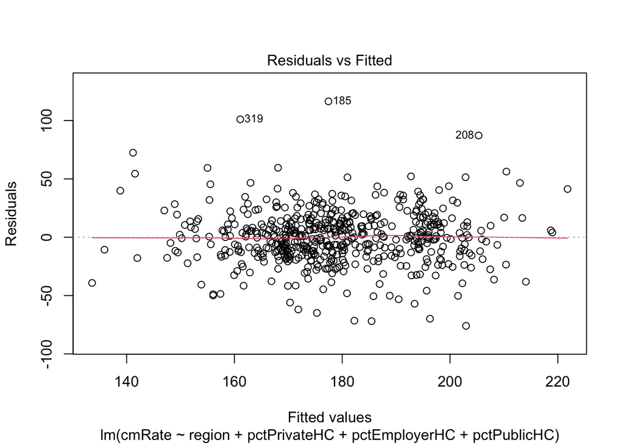

```r
plot(lm_cmRate, which = 1)
```

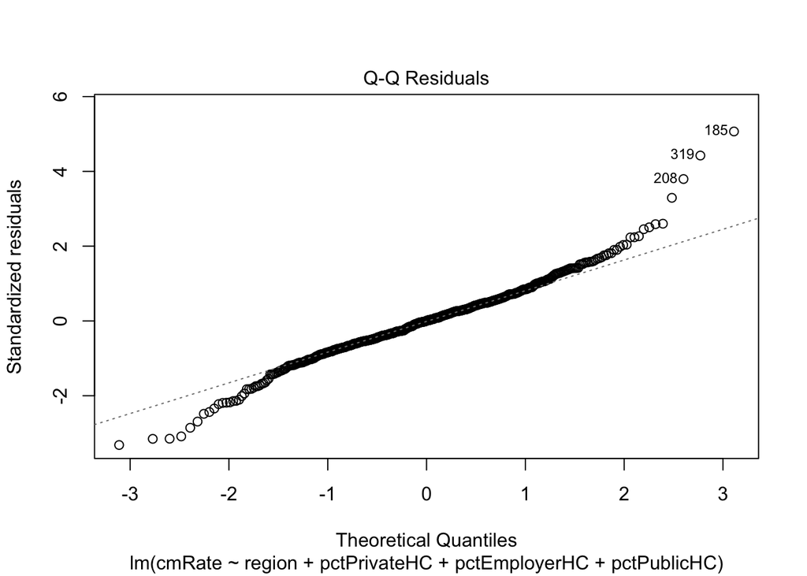

```r
plot(lm_cmRate, which = 2)
```

Is this assumption of linearity reasonably met?

**Answer:** The assumption of linearity is reasonable met as the residuals vs fitted plot follows the zero line approximately.

Is this assumption of constant variance reasonably met?

**Answer:** The assumption of constant variance is reasonably met as the points on the residuals vs fitted plot are approximately evenly spread out throughout the plot.

Is this assumption of normality reasonably met?

**Answer:** The assumption of normality is not reasonably met as there are significant deviations on either side of the tails of the QQ plot.

Taking into account everything you have learned about your data, your goal moving forward will be to improve upon this initial model!

### Conclusions (2 points)

Reflect on your analysis above (in 2 - 4 sentences). Highlight any key findings from your initial data exploration. Where do you plan to go from here?

If you have any questions for the instructional team (about coding, the direction of your analysis, possible transformations, etc.), you can include them here!

Note: I am not looking for anything in particular in this section, just a general summary of your findings!

**Answer:** Overall, most of the predictors followed the trends that I predicted: those with private or employer health coverage have a negative relationship with cancer mortality rate whereas counties/regions with a higher percentage of public or government provided health coverage have a positive relationship with cancer mortality rate. Looking at the scatterplot, it was interesting to see how regions such as the Northeast and Midwest have more concentrated points with higher private health coverage compared to those in the south. This may be due to differences in health care policies between the north and the south. I was surprised to see that the R^2 value for these predictors was relatively low, which prompts me to want to explore some of the other predictors in the data set to try and find any interactions (as the variables chosen here did not have any) and to try and raise this R^2 value to create a better model for cmRate.